# high-dimensional data (focus on dynamical views)

29 Oct 2021

## packages

Some of these packages may be hard to install, i.e. depending on system resources (especially `rggobi`).

```r
library(tourr)
library(rggobi)
library(factoextra)
library(tidyverse)
library(ggalt)
library(rgl)
```

(`ggobi` has been *archived*: use `remotes::install_version("rggobi", "2.1.22")` or `remotes::install_github("ggobi/rggobi")`; see the github repository https://github.com/ggobi/rggobi and the ggobi web site http://ggobi.org/)

## Buja, Cook, and Swayne (1996)

- scatterplots (point locations)
- traces (functions: parallel coordinates, [Andrews plots](https://en.wikipedia.org/wiki/Andrews_plot))
- glyphs (stars/radar charts/faces/etc.)

## tasks

- finding gestalt: focusing views (projection)
- posing queries: brushing/linking
- making comparisons: arranging many views

## focusing: animation/motion

- adds a dimension (2D to 3D)
- smoothness/object continuity
- real-time user control: allows user to search/tune

## interactive example

```r
ggobi(laser)
```

## tours

three components:

- data matrix (\(n \times p\))
- **tour path** that produces a smooth sequence of projection matrices (\(p \times d\)) (`apropos("_tour$")`)
- **display method** that renders the projected data (`apropos("animate_")`)

optional extras (for “guided tour”):

- search strategy (`apropos("^search_")`)
- index (objective) function (`cmass`, `holes`, `lda_pp`)

Goal: allow automated, systematic search through **entire** space of projections

```r
f <- flea[, 1:6]
animate(f,
        ## tour_path = guided_tour(holes()),
        tour_path = grand_tour(),
        display = display_xy(col = flea$species))
```

## available display methods

```r
apropos("animate_")
```

```
##  [1] "animate_andrews"   "animate_density2d" "animate_depth"
##  [4] "animate_dist"      "animate_faces"     "animate_groupxy"
##  [7] "animate_image"     "animate_pca"       "animate_pcp"
## [10] "animate_sage"      "animate_scatmat"   "animate_slice"
## [13] "animate_stars"     "animate_stereo"    "animate_trails"
## [16] "animate_xy"
```

```r
apropos("_tour$")
```

```
##  [1] "dependence_tour"     "frozen_guided_tour"  "frozen_tour"
##  [4] "grand_tour"          "guided_section_tour" "guided_tour"
##  [7] "little_tour"         "local_tour"          "new_tour"
## [10] "planned_tour"
```

## PCA adjustment

Examples/data from Holmes and Huber (2019)

- `prcomp` (SVD): preferred (also `princomp`)
- same data; projects in a way that (hopefully) focuses on interesting angles in the data
- assumes linear features
- normality not necessary, but better-behaved with normal data

## wine PCA example

```r
load("../data/wine.RData")      ## numeric matrix (wine)
load("../data/wineClass.RData") ## metadata (wine.class)

winePCAd <- prcomp(wine, scale = TRUE) ## compute PCA
f0 <- fviz_pca_biplot(winePCAd, geom = "point", habillage = wine.class,
                      col.var = "violet", addEllipses = TRUE, ellipse.level = 0.69)
tmp_plot <- function(p) { ## tweaks
  p + ggtitle("") + coord_fixed() +
    scale_colour_brewer(palette="Dark2") +
    scale_fill_brewer(palette="Dark2")
}
```

## plot

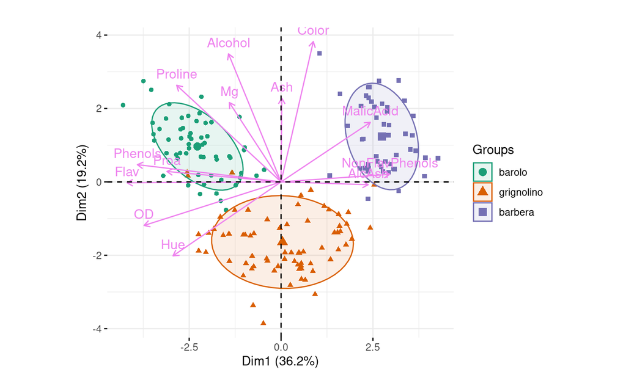

```r
print(tmp_plot(f0))
```

## get augmented data

```r
aug_data <- (get_pca_ind(winePCAd)$coord
  %>% as_tibble()
  %>% mutate(class = wine.class, .before=1)
)
```

## improved plot

```r
f1 <- fviz_pca_biplot(winePCAd, geom = "point", habillage = wine.class,
   col.var = "violet")
f2 <- tmp_plot(f1) + ggalt::geom_encircle(data = aug_data,
                                aes(x=Dim.1,y=Dim.2,group=class,
                                    colour=class,
                                    fill=class),alpha=0.2,
                                show.legend=FALSE)
```

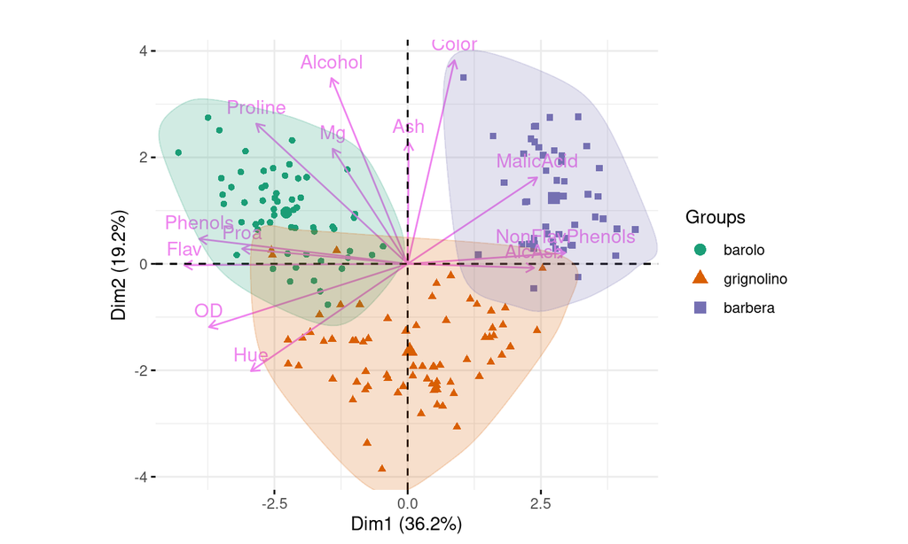

```r
print(f2)
```

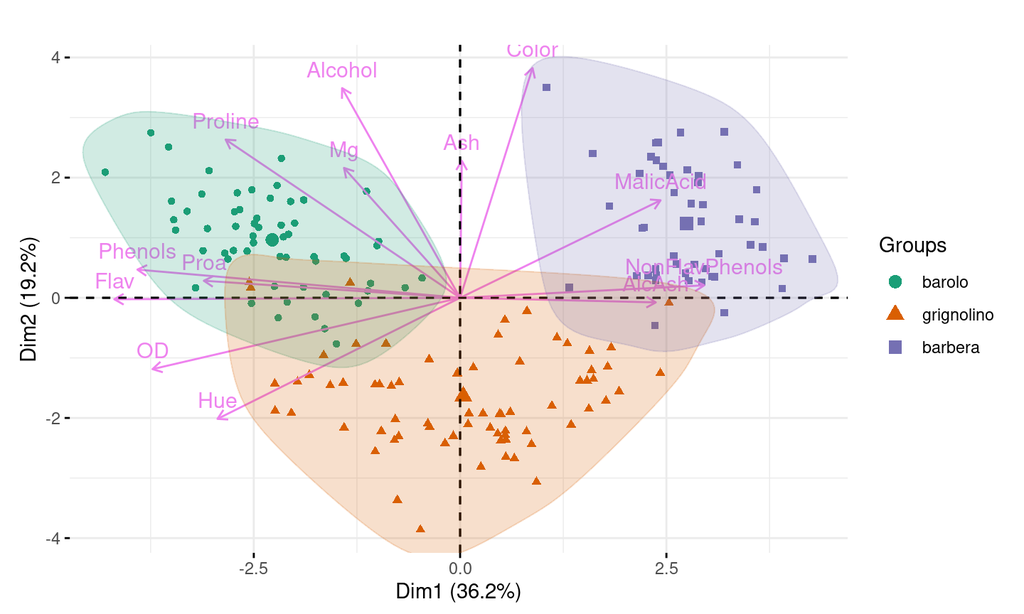

```r
adjust_pcaplot <- function(p, pca, dims=1:2) {
  sdvec <- pca$sdev[dims]
  p + coord_fixed(ratio = sdvec[2]/sdvec[1])
}
f3 <- adjust_pcaplot(f2, winePCAd)
print(f3)
```

```r
cvec <- RColorBrewer::brewer.pal("Dark2", n=3)
with(aug_data,
     plot3d(Dim.1, Dim.2, Dim.3, col=cvec[wine.class], size=4))
with(aug_data,
     plot3d(Dim.1, Dim.2, Dim.3, col=cvec[wine.class], size=2, type = "s"))
```

## references

Buja, Andreas, Dianne Cook, and Deborah F. Swayne. 1996. “Interactive High-Dimensional Data Visualization.” *Journal of Computational and Graphical Statistics* 5 (1): 78–99. https://doi.org/10.2307/1390754.

Holmes, Susan, and Wolfgang Huber. 2019. *Modern Statistics for Modern Biology*. 1 edition. Cambridge: Cambridge University Press.